# Linear regression

### 1. Simple Example with Simulated Data

Testing out a model on simulated data is great, because you can simulate the data in such a way that you know ahead of time what the correct answers should be! It's a great way to build an intuition for how your model works.

For this example, we are going to keep it simple, stay in 2 dimensions, and use OLS to fit a line to some data.

First, I'll generate some data that actually does all live on a straight line, then see if OLS can figure out the equation I used to create the data. The steps will be:

1. Create a list of values for our independent variable (or feature), $x$
2. Create our dependent variable (or target), using $y=1+2x$
3. Use OLS, and see if it can figure out that the parameters of the equation were 1 and 2.

#### 1.1 Generate data

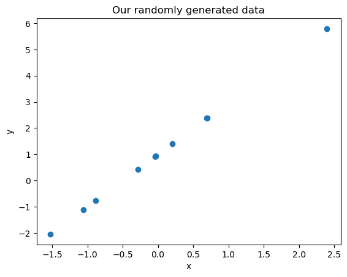

```python
# Generate data

import numpy as np
import matplotlib.pyplot as plt

n = 10
np.random.seed(146)

# Create a list of values for our independent variable (or feature), x
x = np.random.normal(size=(n,1))

# Create our dependent variable (or target), using y=1+2x
y = 1 + 2*x

# Get a scatterplot of x and y
plt.scatter(x,y)
plt.title('Our randomly generated data')
plt.xlabel('x')
plt.ylabel('y')
plt.show()
```

#### 1.2 Fit the model

```python
# Fit the model

from sklearn.linear_model import LinearRegression as LR
lin_reg = LR()
lin_reg.fit(x,y)
```

```
LinearRegression()
```

#### 1.3 Observe the model

```python
# get coefficients
lin_reg.coef_
```

```
array([[2.]])
```

```python
# get intercept
lin_reg.intercept_
```

```
array([1.])
```

```python
# predict y_pred from x

y_pred = lin_reg.predict(x)
```

```python
# compare ground truth y and predicted y_pred
# What do you notice?
for i in range(len(y)):
    print(y[i], y_pred[i])
```

```
[5.79295713] [5.79295713]
[0.92379424] [0.92379424]
[-1.10704509] [-1.10704509]
[-0.76260764] [-0.76260764]
[2.37613321] [2.37613321]
[0.4317582] [0.4317582]
[-2.04866708] [-2.04866708]
[2.39370196] [2.39370196]
[0.93701067] [0.93701067]
[1.41461373] [1.41461373]
```

Predicted values are the same as the ground truth values -- the model is perfectedly fitted!

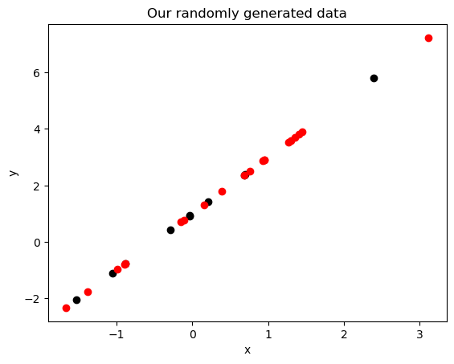

```python
# Use the fitted model to make predictions for new x values

new_x = np.random.normal(size=(20,1))

y_pred = lin_reg.predict(new_x)

# Visualize original data
plt.scatter(x,y, label='Original data', color='k')
# Visualize new data with predicted y
plt.scatter(new_x, y_pred, label='Predicted values', color='r')
plt.title('Our randomly generated data')
plt.xlabel('x')
plt.ylabel('y')
plt.show()
```

### 2. An example with some random noise

This time we will do the same thing, but I'll add a little bit of random noise to the data:

$ y = 1+2x + noise $

```python
n
```

```
10
```

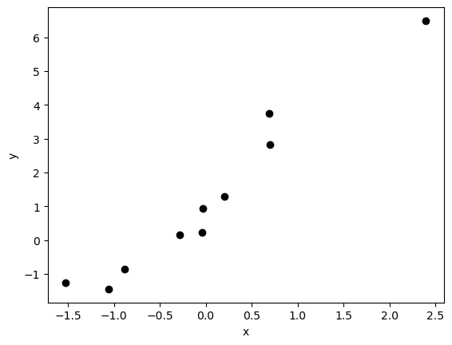

```python
# Generate noisy data

# generate noise with normal distribution
noise_strength = 0.5
np.random.seed(147)
noise = np.random.normal(scale=noise_strength, size=(n,1))

# add noise to y
y = 1 + 2*x + noise

# visualize x and y with scatterplot
plt.scatter(x,y, label='Original data', color='k')
#plt.title('Our randomly generated data')
plt.xlabel('x')
plt.ylabel('y')
plt.show()
```

Do you think we can still get a model that fits every point perfectly? Is it realistic to compare the points manually for a model with many points?

```python
# Fit the model

lin_reg = LR()
lin_reg.fit(x,y)

print('Model coefficient: ', lin_reg.coef_[0][0])
print('Model intercept: ', lin_reg.intercept_[0])
```

```
Model coefficient:  2.2013300386209123
Model intercept:  1.1712556297781649
```

```python
# compare ground truth y and predicted y_pred

y_pred = lin_reg.predict(x)

for i in range(len(y)):
    print(y[i], y_pred[i])
```

```
[6.49089735] [6.44669588]
[0.22415845] [1.08737861]
[-1.45024263] [-1.14789519]
[-0.85443967] [-0.76878495]
[3.74219601] [2.68591731]
[0.15072735] [0.54581176]
[-1.26707095] [-2.18430558]
[2.83504885] [2.70525462]
[0.93547602] [1.10192548]
[1.29285364] [1.62760646]
```

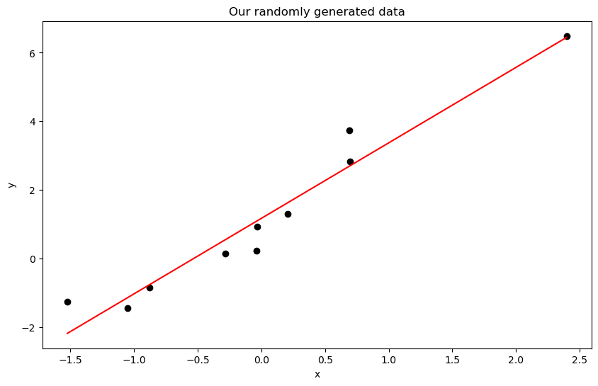

```python
# Visualize the prediction

# generate x and y range (for the model)
x_range = [min(x), max(x)]
y_pred = lin_reg.predict(x_range)



plt.figure(figsize = (10,6))
plt.scatter(x,y, label='Original data', color='k')
#plot the model (red line)
plt.plot(x_range, y_pred, label='Model', color='r')
plt.title('Our randomly generated data')
plt.xlabel('x')
plt.ylabel('y')
plt.show()
```

Why did the model pick the line that it did? The goal was to minimize the sum of the squared errors between the model and the data. Let's plot the errors:

```python
# Visualize the errors with the squares -- the area of the small boxes represents squared error

def VizSquaredErrors(x,y,model):
    # Function will plot x and y, show the best fit line as well as the squared errors, and return the raw error terms

    # Fit the model and plot the data
    model.fit(x,y)
    yp = model.predict(x)
    errors = abs(y - yp)
    plt.scatter(x,y,color='black',label='Actual Data')

    # Compute a range of x values to plot the model as a continuous line
    x_rng = np.linspace(min(x),max(x),20)
    y_pred = model.predict(x_rng)
    plt.plot(x_rng,y_pred,color='red',label='Fitted Model')

    # Draw squares at each data point indicating the squared error
    ax = plt.gca()
    for i,xi in enumerate(x):
        r = plt.Rectangle((xi, min(y[i],yp[i])),width=errors[i],height=errors[i],facecolor='blue',fill=True,alpha=0.1)
        ax.add_patch(r)
    plt.axis('equal')
    plt.xlabel('$x$')
    plt.ylabel('$y$')
    plt.legend()
    plt.show()
    return errors
```

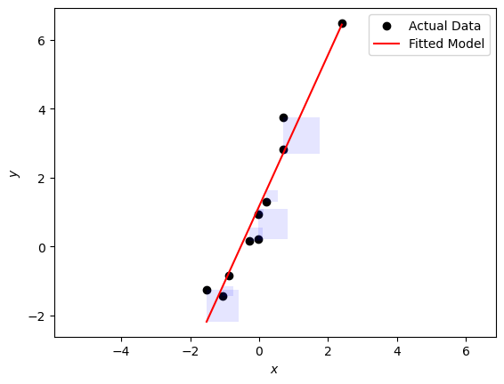

```
array([[0.04420147],
       [0.86322017],
       [0.30234744],
       [0.08565473],
       [1.0562787 ],
       [0.39508441],
       [0.91723463],
       [0.12979423],
       [0.16644946],
       [0.33475283]])
```

```python
VizSquaredErrors(x,y,lin_reg)
```

The red line is the line that minimizes the sum of the squared errors between the model and the data. That is, it makes the total area of all the blue squares as small as possible.

### 3. Scoring the model

The score of a model refers to how well the model fits the data. There is also usually more than one way to score a model!

**Mean-squared error (MSE)** is one way to score a model like this, and it is pretty easy to compute. It is exactly what it sounds like - it is the mean of the squared errors!

We could calculate this by hand:

```python
# Manually calculate MSE (less efficient way but show you what is the math behind)

#We recreate the model just in case we ran other code in between
lin_reg.fit(x, y)

print(np.shape(x), np.shape(y))

# calculate MSE based on the definition

y_pred = lin_reg.predict(x)

errors = y-y_pred

mse = np.mean(errors**2)
mse
```

```
(10, 1) (10, 1)
```

```
0.31156006909071987
```

```python
# Calculate MSE using sklearn

from sklearn.metrics import mean_squared_error

mse = mean_squared_error(y, y_pred)
print(mse)
```

```
0.31156006909071987
```

MSE is the absolute value of errors, but it fails if we want to compare fitness of models with different scales of data. How can we get a score that will give us an idea of how well this model performs, regardless of the scale of the data?

The default scoring method that is used when we call lin_reg.score(x,y) is called $R^2$, or the **coefficient of determination**.

```python
# Get score

print('Model score: ', lin_reg.score(x,y))
print('Model MSE: ', mean_squared_error(lin_reg.predict(x),y))
```

```
Model score:  0.9449458126811453
Model MSE:  0.31156006909071987
```

```python
# The coefficient of determination is the correlation coefficient squared

r = np.corrcoef(x,y,rowvar=False)[0][1]
print(r)
print(r**2)
```

```
0.9720832334122141
0.9449458126811452
```

### 4. Non-linear models

Back to simulated data for a second, this time it'll be generated based on:

$$ y = 1 + 2\sin(x) + noise $$

Which is certainly nothing close to a straight line.

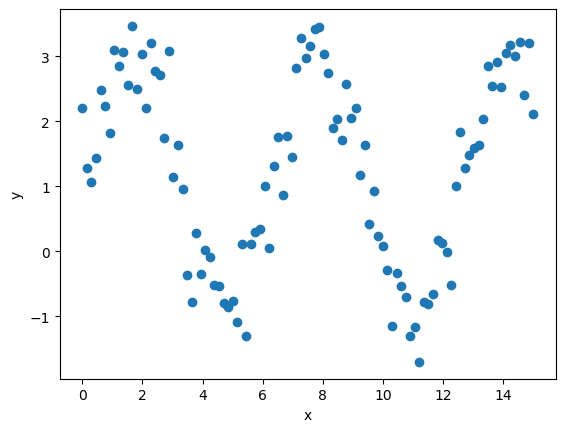

```python
# Generate data

# uniformally generate 100 x values from [0,15]
n = 100
x = np.linspace(0,15,n)


# generate noise
noise_strength=0.5
np.random.seed(146)
noise = np.random.normal(scale=noise_strength,size=n)

# generate y
y = 1 + 2*np.sin(x) + noise

# scatterplot of x and y
plt.scatter(x,y)
plt.xlabel('x')
plt.ylabel('y')
plt.show()
```

```
0.0027690820574749475
```

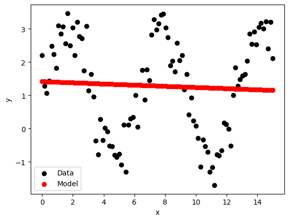

```python
# Fit a linear model
#What do you think of this?

lin_reg = LR()
lin_reg.fit(x.reshape(-1,1),y)

print(lin_reg.score(x.reshape(-1,1), y))

y_pred = lin_reg.predict(x.reshape(-1,1))

# scatterplot of data
plt.scatter(x,y, label='Data', color='k')
# scatterplot of the model
plt.scatter(x, y_pred, label='Model', color='r')
plt.xlabel('x')
plt.ylabel('y')
plt.legend()
plt.show()
```

I'm going to take our equation above, and make a new variable: $$z =\sin(x)$$

Then the equation looks like this: $$y=1+2z + noise $$

Aside from having a $z$ instead of an $x$, it now looks identical to one of our first examples, right?

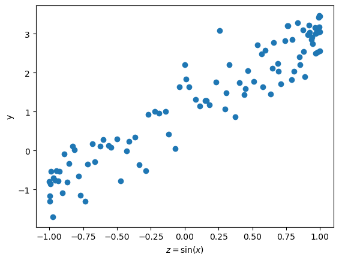

```python
# Transform data with np.sin()

z = np.sin(x)

# Visualize the transformed data z and y; they look linearly correlated now!
plt.scatter(z,y)
plt.xlabel('$z=\sin(x)$')
plt.ylabel('y')
plt.show()
```

Ooooohhhhh.....we just had to manipulate the data a bit to get a line.

```python
# Fit it again with lin_reg; See what is the input/feature now?

lin_reg.fit(z.reshape(-1,1),y)
lin_reg.score(z.reshape(-1,1),y)
```

```
0.8914793482862062
```

### 5. OLS on real data (Multiple linear regression)

#### 5.1 Fit & score the model

```python
import numpy as np
import matplotlib.pyplot as plt
from sklearn.linear_model import LinearRegression as LR

import pandas as pd
concrete = pd.read_excel('./data/Concrete_Data.xls')
concrete.head()
```

|  | Cement (component 1)(kg in a m^3 mixture) | Blast Furnace Slag (component 2)(kg in a m^3 mixture) | Fly Ash (component 3)(kg in a m^3 mixture) | Water (component 4)(kg in a m^3 mixture) | Superplasticizer (component 5)(kg in a m^3 mixture) | Coarse Aggregate (component 6)(kg in a m^3 mixture) | Fine Aggregate (component 7)(kg in a m^3 mixture) | Age (day) | Concrete compressive strength(MPa, megapascals) |
| --- | --- | --- | --- | --- | --- | --- | --- | --- | --- |
| 0 | 540.0 | 0.0 | 0.0 | 162.0 | 2.5 | 1040.0 | 676.0 | 28 | 79.986111 |
| 1 | 540.0 | 0.0 | 0.0 | 162.0 | 2.5 | 1055.0 | 676.0 | 28 | 61.887366 |
| 2 | 332.5 | 142.5 | 0.0 | 228.0 | 0.0 | 932.0 | 594.0 | 270 | 40.269535 |
| 3 | 332.5 | 142.5 | 0.0 | 228.0 | 0.0 | 932.0 | 594.0 | 365 | 41.052780 |
| 4 | 198.6 | 132.4 | 0.0 | 192.0 | 0.0 | 978.4 | 825.5 | 360 | 44.296075 |

```python
# Simplify column names

concrete.columns = [item.split('(')[0].rstrip().replace(' ','_') for item in concrete.columns]
concrete.head()
```

|  | Cement | Blast_Furnace_Slag | Fly_Ash | Water | Superplasticizer | Coarse_Aggregate | Fine_Aggregate | Age | Concrete_compressive_strength |
| --- | --- | --- | --- | --- | --- | --- | --- | --- | --- |
| 0 | 540.0 | 0.0 | 0.0 | 162.0 | 2.5 | 1040.0 | 676.0 | 28 | 79.986111 |
| 1 | 540.0 | 0.0 | 0.0 | 162.0 | 2.5 | 1055.0 | 676.0 | 28 | 61.887366 |
| 2 | 332.5 | 142.5 | 0.0 | 228.0 | 0.0 | 932.0 | 594.0 | 270 | 40.269535 |
| 3 | 332.5 | 142.5 | 0.0 | 228.0 | 0.0 | 932.0 | 594.0 | 365 | 41.052780 |
| 4 | 198.6 | 132.4 | 0.0 | 192.0 | 0.0 | 978.4 | 825.5 | 360 | 44.296075 |

```python
# Separate X and y into two dataframes

X = concrete.drop(columns = ['Concrete_compressive_strength'])
y = concrete['Concrete_compressive_strength'].values
```

```python
# fit the model, get R^2

lin_reg = LR()
lin_reg.fit(X,y)
lin_reg.score(X,y)
```

```
0.6154647342687214
```

```python
# get MSE

from sklearn.metrics import mean_squared_error
mean_squared_error(lin_reg.predict(X),y)
```

```
107.21180273450533
```

We will compare the predicted values to the actual values we had for y. What does it mean to make a prediction?

```python
# showing you the math behind lin_reg.predict()

obs = np.array(X.iloc[0])
print('Observation:', obs, '\n')
print('Coefficients:', lin_reg.coef_, '\n')
print('Intercept:', lin_reg.intercept_, '\n')
sum(obs * lin_reg.coef_) + lin_reg.intercept_
```

```
Observation: [ 540.     0.     0.   162.     2.5 1040.   676.    28. ]

Coefficients: [ 0.11978526  0.10384725  0.08794308 -0.1502979   0.29068694  0.01803018
  0.02015446  0.11422562]

Intercept: -23.163755811078822
```

```
53.472859099719024
```

```python
# same value as the above! why?
lin_reg.predict([obs])
```

```
array([53.4728591])
```

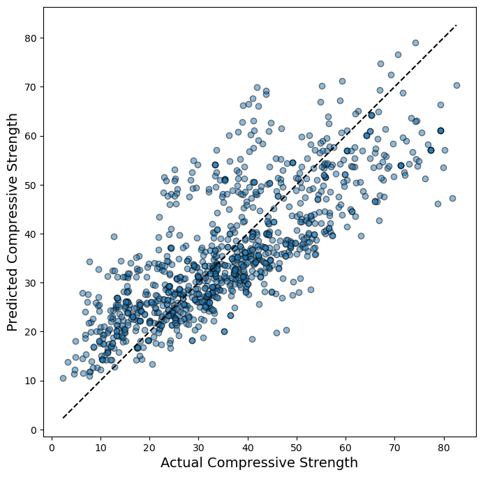

```python
# Visualize prediction -- perfect prediction means all dots are on the dashed diagonal line (y=x)

y_pred = lin_reg.predict(X)

plt.figure(figsize=(8,8))
plt.scatter(y, y_pred, alpha=0.5, ec='k')
# plotting the dashed diagnal
plt.plot([min(y), max(y)],[min(y),max(y)], '--k')
plt.axis('equal')
plt.xlabel('Actual Compressive Strength', fontsize=14)
plt.ylabel('Predicted Compressive Strength', fontsize=14)
plt.show()
```

#### 5.2 The effect of pre-processing

Can we do better using Principal Components?

```python
from sklearn.decomposition import PCA
from sklearn.preprocessing import StandardScaler as SS
```

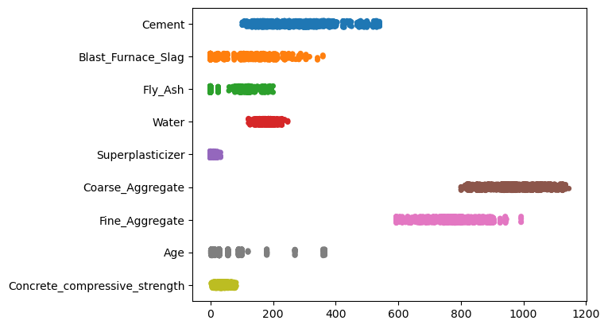

```python
#Do we need to scale the data???
#Go to slide?
import seaborn as sns
sns.stripplot(data = concrete, orient = 'h')
```

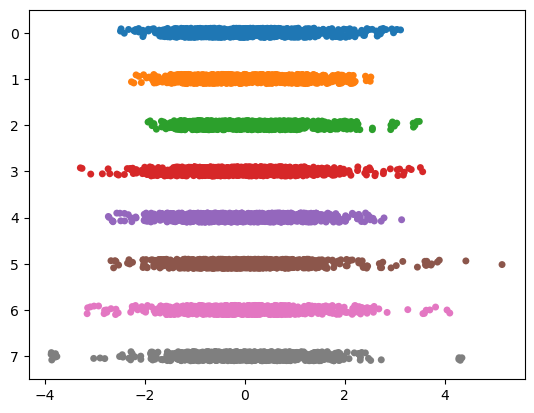

```python
# do standard scaling before PCA

ss = SS()
X_scaled = ss.fit_transform(X)

sns.stripplot(data = X_scaled, orient = 'h')
```

```python
# PCA transformation

pca = PCA()
pca_X = pca.fit_transform(X_scaled)
```

```python
# think: what does each number mean? how is each number calculated? Do the same for the following 2 as well
pca.explained_variance_
```

```
array([2.28210403, 1.41758764, 1.3415455 , 1.01513995, 0.95252658,
       0.79089808, 0.17790128, 0.03007148])
```

```python
pca.explained_variance_ratio_
```

```
array([0.28498605, 0.17702642, 0.16753038, 0.1267693 , 0.11895022,
       0.09876628, 0.02221607, 0.00375529])
```

```python
np.cumsum(pca.explained_variance_ratio_)
```

```
array([0.28498605, 0.46201247, 0.62954284, 0.75631214, 0.87526237,
       0.97402864, 0.99624471, 1.        ])
```

```python
# Fit the model after SS and PCA

lin_reg = LR()
X = pca_X[:,:6]

lin_reg.fit(X,y)
lin_reg.score(X,y)
```

```
0.5651274964358977
```

```python
# Trend of R^2 score by taking different number of PCs
# what are the 8 printed values? Which one is the same as the above and why?

for i in range(1,len(pca.explained_variance_ratio_)+1):
    lin_reg = LR()
    X = pca_X[:,:i]
    lin_reg.fit(X,y)
    #print(mean_squared_error(lin_reg.predict(X),y))
    print(lin_reg.score(X,y))
```

```
0.00229144068487952
0.03236818339746361
0.3333775331909373
0.33337758099668935
0.4407687937872554
0.5651274964358977
0.6005314246794745
0.6154647342687214
```